# 데이터 가져오기 - IoT

IoT 센서 - JSON

xwMOOC

2019-05-01

# 1 IoT 센서 데이터셋 [^1]

[City Puls, “Dataset Collection”](http://iot.ee.surrey.ac.uk:8080/datasets.html#weather) 웹페이지를 통해서 사물인터넷 관련 탐색적 데이터 분석에 적합한 센서가 생성한 다양한 데이터를 받아낼 수 있다.

- [Weather Data for the City of Aarhus in Denmark, “February-June 2014”](http://iot.ee.surrey.ac.uk:8080/datasets.html#weather)
  - [Raw Weather Dataset in JSON format](http://iot.ee.surrey.ac.uk:8080/datasets/weather/feb_jun_2014/raw_weather_data_aarhus.tar.gz)
- Humidity (percentage)
- Pressure in mBar
- Temperature in degrees Celsius
- Wind direction in degrees
- Wind speed in kilometers per hour (kph)

상기 센서데이터는 JSON 파일형태로 된 전형적인 IoT 센서 데이터라고 볼 수 있다.

```r
library(tidyverse)

download.file(url="http://iot.ee.surrey.ac.uk:8080/datasets/weather/feb_jun_2014/raw_weather_data_aarhus.tar.gz", destfile = "data/raw_weather_data_aarhus.tar.gz")

dir.create("data/weather")

untar("data/raw_weather_data_aarhus.tar.gz", exdir = "data/weather")
```

즉, `http://iot.ee.surrey.ac.uk:8080/datasets/weather/feb_jun_2014/raw_weather_data_aarhus.tar.gz` 파일을 다운로드 받아 `data/raw_weather_data_aarhus.tar.gz` 파일명어로 저장하고 압축파일을 `untar()` 명령어로 압축을 푼다. 그리고 나서 `system()` 명령어로 압축이 풀린 것을 확인한다.

```r
system("cmd.exe /c dir data\\weather", intern = TRUE)
```

```
 [1] " D 드라이브의 볼륨에는 이름이 없습니다."
 [2] " 볼륨 일련 번호: 1C4A-327C"
 [3] ""
 [4] " D:\\docs\\ingest-data\\data\\weather 디렉터리"
 [5] ""
 [6] "2019-05-01  오후 06:28    <DIR>          ."
 [7] "2019-05-01  오후 06:28    <DIR>          .."
 [8] "2014-11-04  오전 12:45           243,245 dewptm.txt"
 [9] "2014-11-04  오전 12:45           238,641 hum.txt"
[10] "2014-11-04  오전 12:45           254,442 pressurem.txt"
[11] "2014-11-04  오전 12:45           244,864 tempm.txt"
[12] "2014-11-04  오전 12:45           249,436 vism.txt"
[13] "2014-11-04  오전 12:45           244,817 wdird.txt"
[14] "2014-11-04  오전 12:45           251,443 wspdm.txt"
[15] "               7개 파일           1,726,888 바이트"
[16] "               2개 디렉터리  11,804,725,248 바이트 남음"
```

# 2 센서 데이터셋 → R

이제 센서 데이터셋을 R로 불러읽어 들인다. JSON 파일형식이라 이것을 데이터프레임으로 변환을 시킨다. 그리고 나서 시간대별로 `timestamp` 날짜시간형태로 변환을 시키고, 습도, 온도, 압력, 풍속 등을 문자형에서 숫자형으로 변환을 시킨다.

```r
library(rjson)

## 습도 데이터 ----
hum_list <- rjson::fromJSON(file = "data/weather/hum.txt")

hum_df <- tibble(
  timestamp = names(hum_list),
  humidity = map_chr(hum_list, 1)) %>%
  mutate(timestamp = lubridate::ymd_hms(timestamp))

## 습도 데이터 ----
pressure_list <- rjson::fromJSON(file = "data/weather/pressurem.txt")

pressure_df <- tibble(
  timestamp = names(pressure_list),
  pressure = map_chr(pressure_list, 1)) %>%
  mutate(timestamp = lubridate::ymd_hms(timestamp))

## 온도 데이터 ----
temp_list <- rjson::fromJSON(file = "data/weather/tempm.txt")

temp_df <- tibble(
  timestamp = names(temp_list),
  temp = map_chr(temp_list, 1)) %>%
  mutate(timestamp = lubridate::ymd_hms(timestamp))

## 풍량 데이터 ----
wind_list <- rjson::fromJSON(file = "data/weather/wspdm.txt")

wind_df <- tibble(
  timestamp = names(wind_list),
  wind = map_chr(wind_list, 1)) %>%
  mutate(timestamp = lubridate::ymd_hms(timestamp))

## 센서 데이터 병합 ----
sensor_df <- hum_df %>%
  full_join(temp_df) %>%
  full_join(pressure_df) %>%
  full_join(wind_df) %>%
  mutate_if(is_character, as.numeric)

sensor_df %>%
  DT::datatable()
```

|  | timestamp | humidity | temp | pressure | wind |
| --- | --- | --- | --- | --- | --- |
| 1 | 2014-02-13T06:20:00Z | 93 | 3 | 989 | 16.7 |
| 2 | 2014-02-13T13:50:00Z | 66 | 7 | 989 | 14.8 |
| 3 | 2014-02-13T06:00:00Z | 91 | 2 | 990 | 13 |
| 4 | 2014-02-13T03:00:00Z | 84 | 3 | 992 | 20.4 |
| 5 | 2014-02-13T13:00:00Z | 62 | 6 | 990 | 20.4 |
| 6 | 2014-02-13T18:50:00Z | 75 | 4 | 991 | 13 |
| 7 | 2014-02-13T13:20:00Z | 70 | 6 | 990 | 16.7 |
| 8 | 2014-02-13T15:00:00Z | 56 | 6 | 990 | 14.8 |
| 9 | 2014-02-13T08:50:00Z | 87 | 4 | 989 | 13 |
| 10 | 2014-02-13T21:50:00Z | 75 | 4 | 993 | 7.4 |

[output cut: 60 more lines]

# 3 탐색적 데이터 분석

## 3.1 시계열 그래프

가장 먼저 시계열 데이터라서 이를 시간대별 변화를 각 센서별로 시각화시킨다.

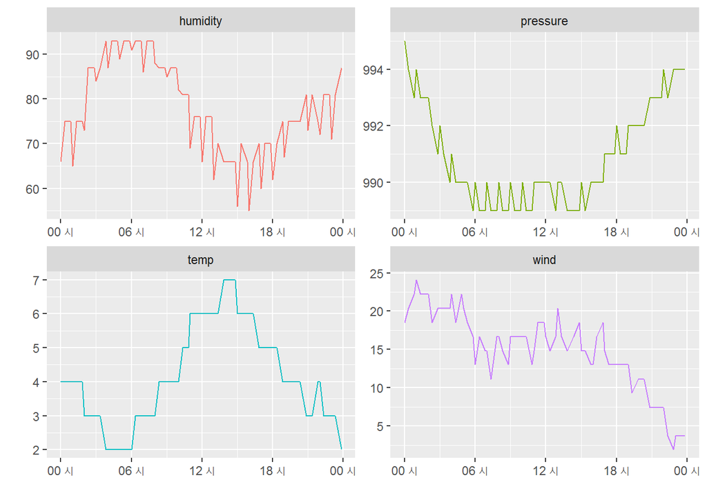

```r
sensor_df %>%
  gather(sensor, value, -timestamp) %>%
  ggplot(aes(x=timestamp, y=value, color=sensor)) +
    geom_line(show.legend = FALSE) +
    facet_wrap(~sensor, scales = "free") +
    labs(x="", y="") +
    scale_x_datetime(date_labels = "%H 시")
```